# Анализ связи между наборами данных

## Вы сможете

- Количественно оценить степень взаимосвязи между несколькими наборами данных.
- Найти ортимальное сочетание признаков, не вошедших в ординацию, которые "объясняют" характер взаиморасположения точек на ординации

## Тест Мантела

## Постановка проблемы

Нам необходимо оценить свзаны ли, вцелом, два набора данных и оценить силу этой связи

> Зависит ли растительность от параметров среды? Связаны ли морфологические признаки и экспрессия генов? Связаны ли характеристики паразитов и хозяев?

и т.п.

## Метод сравнения сопряженных матриц, описывающих попарные расстояния (или сходства), был предложен Натаном Мантелом

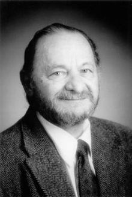

Если две матрицы сопряжены, то меры сходства/различия в одной матрице должны быть подобны мерам сходства/различия в другой матрице

```r
library(vegan)
data(varespec)
data(varechem)
dist_com <- vegdist(varespec, method = "bray")
dist_chem <- vegdist(varechem, method = "euclidean")
```

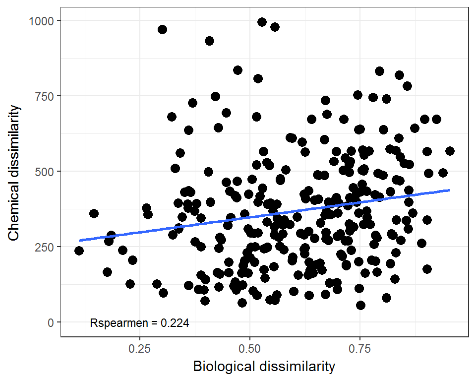

## Корреляция матриц сходства/различия

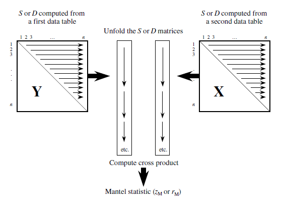

Внимание! Достоверность этой корреляции нельзя оценивать как обычную корреляцию, например функцией `cor.test()` или по таблице пороговых значений коэффициента корреляции.

## Проверка достоверности Мантеловской корреляции

Для оценки достоверности Мантеловской корреляции применяется пермутационная процедура. Эта процедура реализована в функции mantel()

```r
options(digits=4)
mant <- mantel(dist_com, dist_chem, method="spearman", permutations = 999)
mant
```

```
##
## Mantel statistic based on Spearman's rank correlation rho
##
## Call:
## mantel(xdis = dist_com, ydis = dist_chem, method = "spearman",      permutations = 999)
##
## Mantel statistic r: 0.224
##       Significance: 0.005
##
## Upper quantiles of permutations (null model):
##   90%   95% 97.5%   99%
## 0.104 0.136 0.165 0.192
## Permutation: free
## Number of permutations: 999
```

Вероятность наблюдать такое значение при условии, что верна \(H_0\), равна 0.005

## Частная Мантеловская корреляция

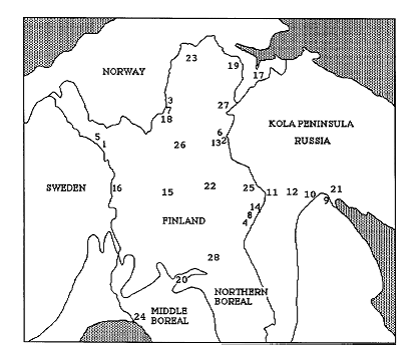

из Väre, Ohtonen & Oksanen (1995)

В материале есть одна проблема

- сходство между отдельными описаниями может быть обусловлено не только их биологическими свойствами, но и тем, что они просто располагаются ближе друг к другу в пространстве.
- Корреляция между биологическими признаками и химическими должна оцениваться при учете еще одной матрицы - **Матрицы географических расстояний**

## Частная Мантеловская корреляция

```r
mantel_partial <- mantel.partial(dist_com, dist_chem, dist_geo, method = "pearson", permutations = 9999)
mantel_partial
```

```
##
## Partial Mantel statistic based on Pearson's product-moment correlation
##
## Call:
## mantel.partial(xdis = dist_com, ydis = dist_chem, zdis = dist_geo,      method = "pearson", permutations = 9999)
##
## Mantel statistic r: 0.182
##       Significance: 0.022
##
## Upper quantiles of permutations (null model):
##   90%   95% 97.5%   99%
## 0.112 0.146 0.175 0.208
## Permutation: free
## Number of permutations: 9999
```

## Часть 3. Подбор оптимальной модели: процедура BIO-ENV

## Постановка задачи

Необходимо выбрать предикторы, которые наилучшим образом объясняют поведение биологической системы.

\(NB!\) Эта задача аналогична задачам, ставящимся в регрессионном анализе.

К. Кларком и M. Эинсвортом был предложен метод BIO-ENV (Clarke, Ainsworth, 1993). Это непараметрический аналог пошагового регрессионного анализа.

## Процедура BIO-ENV

В этом анализе есть две сцепленные матрицы:

- Зависимая матрица (BIO) - матрица геоботанических описаний.
- Матрица-предиктор (ENV) - матрица химических параметров.

## Алгоритм процедуры BIO-ENV

- Вычисляется матрица взаимных расстояний между объектами для зависимой матрицы \(D_{BIO}\). Используются все ее перменные.
- Матрица-предиктор имеет \(p\) переменных. Вычисляются все возможные матрицы взаимных расстояний между объектами для всех возможных комбинаций признаков матрицы ENV - \(D_{ENV_i}\). ВНИМАНИЕ! Таких матриц будет \(2^p-1\).
- Между каждой из матриц \(D_{ENV_i}\) и матрицей \(D_{BIO}\) вычисляется мантеловская корреляция.
- Находится матрица \(D_{ENV_i}\), имеющая максимальное значение мантеловской корреляции.
- Выводятся признаки матрицы ENV, на основе которых получена максимально подобная матрица \(D_{ENV_i}\).

## Функция bioenv() из пакета vegan

```r
BioEnv <- bioenv(varespec, varechem, method = "spearman", index = "bray")
```

```
## 16383 possible subsets (this may take time...)
```

```r
BioEnv
```

```
##
## Call:
## bioenv(comm = varespec, env = varechem, method = "spearman",      index = "bray")
##
## Subset of environmental variables with best correlation to community data.
##
## Correlations:    spearman
## Dissimilarities: bray
## Metric:          euclidean
##
## Best model has 5 parameters (max. 14 allowed):
## N P Al Mn Baresoil
## with correlation  0.4494
```

Внимание! Не надо оценивать достоверность результата процедуры BIO-ENV путем оценки достоверности мантеловской корреляции между \(D_{BIO}\) и матрицей, полученной в результате применения BIO-ENV \(D_{ENV}\). **Это будет жульничеством**, так как это уже максимально подобная матрица.  
Для оценки достоверности полученного результата применяется пермутационный метод, основанный на **многократном повторении самой процедуры BIO-ENV**.  
Внимание! Это занимает очень много времени

## Алгоритм оценки достоверности применения процедуры BIO-ENV

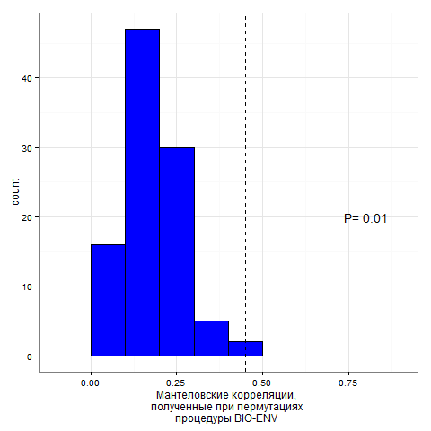

1. Применяем процедуру BIO-ENV и находим лучшее сочетание переменных в матрице-предикторе (ENV).
2. Пермутируем зависимую матрицу (BIO).
3. Применяем процедуру BIO-ENV к пермутированной матрице и вновь находим наилучшее сочетание и записываем значение мантеловской корреляции.
4. Поворяя шаги 2 и 3 многократно, получаем распределение пермутационных статистик.
5. Вычисляем уровень значимости способом, принятым при пермутционной оценке.

## Трактовка результатов BIO-ENV?

Задание: Постройте ординацию описаний в осях nMDS и отразите на этой диаграмме вектора, соответствующие результатам процедуры `BIO-ENV`

## Решение

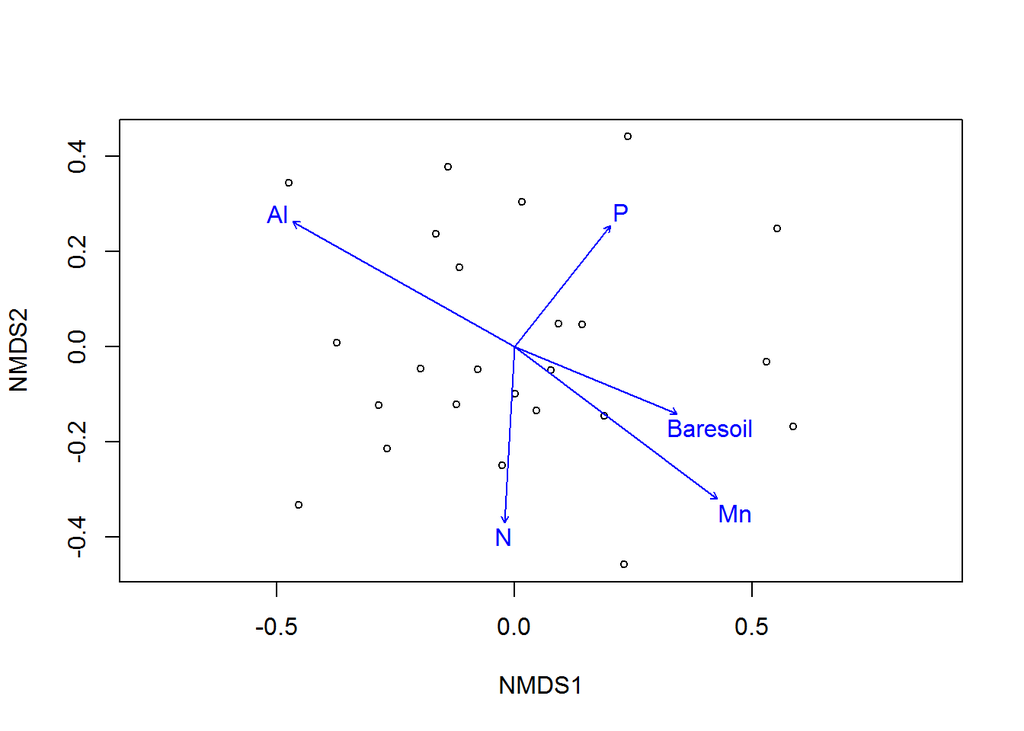

```r
plot(veg_ord, display = "site")
plot(envfit(veg_ord ~ N + P + Al + Mn + Baresoil, data = varechem ))
```

## Summary

- Степень сопряженности двух наборов пизнаков можно оценивать с помощью теста Мантела.
- Оценка достоверности теста Мантела и корреляций с признаками, вычисленными в процедуре `envfit()` проводится пермутационным методом
- С помощью процедуры `BIO-ENV` можно выявить набор переменных в матрице-предикторе, которые обеспечивают наибольшее сходство с завивисимой матрицей.

## Другое программное обеспечение

PRIMER 6.

Здесь реализована расширенная процедура `BEST`.  
Она позволяет проводить не только полный перебор всех переменных в матрице-предикторе (Bio-Env), но и оптимизировать эту процедуру (BVStep). Кроме того, есть возможность оценивать достоверность результатов анализа. Но работает так же медленно.

## Что почитать

- Oksanen, J., 2011. Multivariate analysis of ecological communities in R: vegan tutorial. R package version 2–0.
- Clarke, K. R & Ainsworth, M. 1993. A method of linking multivariate community structure to environmental variables. Marine Ecology Progress Series, 92, 205–219.
- Clarke, K. R., Gorley R. N. (2006) PRIMER v6: User Manual/Tutorial. PRIMER-E, Plymouth.
- Legendre P., Legendre L. (2012) Numerical ecology. Second english edition. Elsevier, Amsterdam. (В этом издании приводятся ссылки на реализацию методов в R)